# Classify images according to cell-type

In this notebook the goal is to classify the images according to their cell-type

# Setup

1. Import libraries
2. Setting up data sets
3. Initialize learning curve function

```python
import tensorflow as tf
AUTOTUNE = tf.data.experimental.AUTOTUNE

import IPython.display as display
from PIL import Image
import numpy as np
import matplotlib.pyplot as plt
import os

import pandas as pd

tf.__version__
```

```
'2.3.0'
```

```python
from sklearn.model_selection import train_test_split

data = pd.read_csv('./data_labels_mainData.csv')

train_data, test_data = train_test_split(data, test_size=0.2, random_state=42)
train_data, val_data = train_test_split(train_data, test_size=0.25, random_state=42)

print("Train data : {}, Val Data: {}, Test Data: {}".format(train_data.shape[0], val_data.shape[0], test_data.shape[0]))
```

```
Train data : 5937, Val Data: 1979, Test Data: 1980
```

# EDA

Exploring the data set

```python
train_data.head()
```

|  | InstanceID | patientID | ImageName | cellTypeName | cellType | isCancerous |
| --- | --- | --- | --- | --- | --- | --- |
| 9533 | 22266 | 58 | 22266.png | fibroblast | 0 | 0 |
| 310 | 18717 | 4 | 18717.png | others | 3 | 0 |
| 9480 | 21202 | 57 | 21202.png | inflammatory | 1 | 0 |
| 7073 | 18114 | 44 | 18114.png | fibroblast | 0 | 0 |
| 8977 | 14070 | 54 | 14070.png | epithelial | 2 | 1 |

```python
train_data.info()
```

```
<class 'pandas.core.frame.DataFrame'>
Int64Index: 5937 entries, 9533 to 9349
Data columns (total 6 columns):
 #   Column        Non-Null Count  Dtype
---  ------        --------------  -----
 0   InstanceID    5937 non-null   int64
 1   patientID     5937 non-null   int64
 2   ImageName     5937 non-null   object
 3   cellTypeName  5937 non-null   object
 4   cellType      5937 non-null   int64
 5   isCancerous   5937 non-null   int64
dtypes: int64(4), object(2)
memory usage: 324.7+ KB
```

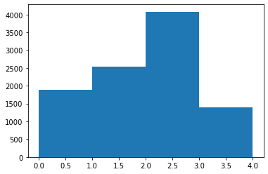

```python
import matplotlib.pyplot as plt

target = data['cellType']

plt.hist(target, bins=np.arange(5))
```

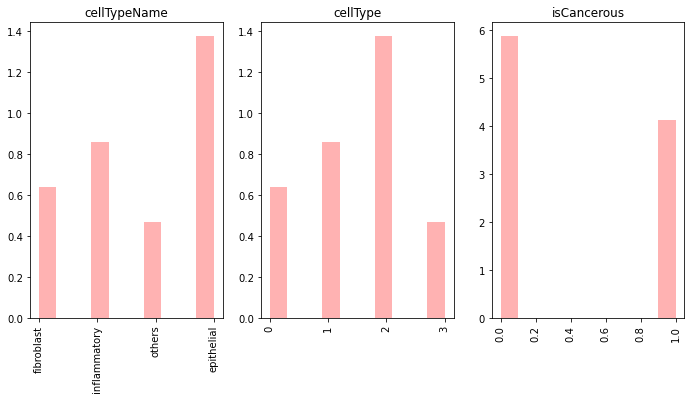

```python
plt.figure(figsize=(20,25))
for i, col in enumerate(['cellTypeName','cellType', 'isCancerous']):
    plt.subplot(4,5,i+1)
    _, bins, _ = plt.hist(data[col], alpha=0.3, color='r', density=True)
    plt.title(col)
    plt.xticks(rotation='vertical')
```

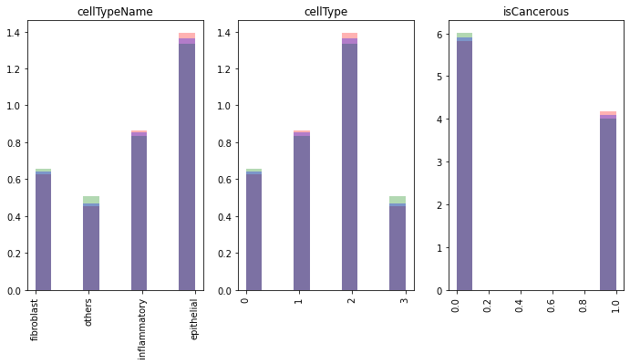

```python
plt.figure(figsize=(20,25))
for i, col in enumerate(['cellTypeName','cellType', 'isCancerous']):
    plt.subplot(4,5,i+1)
    _, bins, _ = plt.hist(train_data[col], alpha=0.3, color='r', density=True)
    _, bins2, _ = plt.hist(test_data[col], bins=bins, alpha=0.3, color='g', density=True)
    plt.hist(val_data[col], bins=bins2, alpha=0.3, color='b', density=True)
    plt.title(col)
    plt.xticks(rotation='vertical')
```

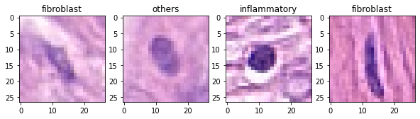

```python
from PIL import Image

label_names = {'fibroblast' : 0, 'inflammatory' : 1, 'epithelial' : 2, 'others' : 3}
d_inv = {v: k for k, v in label_names.items()}

img_list = list('./patch_images/'+train_data['ImageName'])
target = train_data['cellType']
target_list = list(target)

fig = plt.figure(figsize=[10,10])

for i in np.arange(4):
    plt.subplot(1, 4, i+1)
    img = Image.open(img_list[i])

    plt.imshow(img)
    plt.title(d_inv[int(target_list[i])])
```

```python
# check image size

img = Image.open(img_list[100])
img_numpy = np.ascontiguousarray(img, dtype=np.float32)
print('Image size \nH:{} W:{} C:{}'.format(img_numpy.shape[0], img_numpy.shape[1], img_numpy.shape[2]))
```

```
Image size
H:27 W:27 C:3
```

### Observations

1. We observe that the data is evenly distributed among the train, test and validation sets.
2. The cell type data is slightly imbalanced as there are more sample of epithelial compared to the rest, but it is not too skewed such as a 1:9 thus we decide to keep it as is

### Further setups

```python
# learning curve function
import matplotlib.pyplot as plt
def plot_learning_curve(train_loss, val_loss, train_metric, val_metric, metric_name='Accuracy'):
    plt.figure(figsize=(10,5))

    plt.subplot(1,2,1)
    plt.plot(train_loss, 'r--')
    plt.plot(val_loss, 'b--')
    plt.xlabel("epochs")
    plt.ylabel("Loss")
    plt.legend(['train', 'val'], loc='upper left')

    plt.subplot(1,2,2)
    plt.plot(train_metric, 'r--')
    plt.plot(val_metric, 'b--')
    plt.xlabel("epochs")
    plt.ylabel(metric_name)
    plt.legend(['train', 'val'], loc='upper left')

    plt.show()
```

```python
# cellType needs to be string
train_data['cellType'] = train_data['cellType'].astype('str')
val_data['cellType'] = val_data['cellType'].astype('str')
```

# 1) NN model as Base model

We will use a simple NN model using Keras Sequential for our base model

### Setting up generators

```python
import tensorflow as tf
INPUT_DIM = (27,27,3)
HIDDEN_LAYER_DIM = 256
OUTPUT_CLASSES = 4

from tensorflow.keras.preprocessing.image import ImageDataGenerator

train_datagen = ImageDataGenerator(rescale=1./255, data_format='channels_last')
val_datagen = ImageDataGenerator(rescale=1./255, data_format='channels_last')

batch_size = 32

train_generator = train_datagen.flow_from_dataframe(
        dataframe=train_data,
        directory='./patch_images/',
        x_col="ImageName",
        y_col="cellType",
        target_size=(27, 27),
        batch_size=batch_size,
        class_mode='categorical')

validation_generator = val_datagen.flow_from_dataframe(
        dataframe=val_data,
        directory='./patch_images/',
        x_col="ImageName",
        y_col="cellType",
        target_size=(27, 27),
        batch_size=batch_size,
        class_mode='categorical')
```

```
Found 5937 validated image filenames belonging to 4 classes.
Found 1979 validated image filenames belonging to 4 classes.
```

### Setting up base model

Parameter settings for the base model:

1. units = HIDDEN_LAYER_DIM = 256
2. no reg
3. no dropout
4. sigmoid activation
5. epochs = 150

These values are estimates and would be change accordingly during hyperparameters tuning

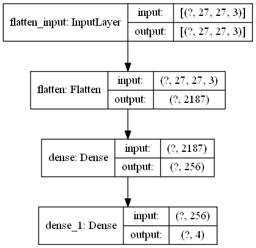

```python
# base_model
# initialize layers
base_model = tf.keras.Sequential([
    tf.keras.layers.Flatten(input_shape=INPUT_DIM),
    tf.keras.layers.Dense(units=HIDDEN_LAYER_DIM, activation='sigmoid'),
    tf.keras.layers.Dense(OUTPUT_CLASSES)
])

tf.keras.utils.plot_model(base_model, show_shapes=True)
```

```
WARNING:tensorflow:From <ipython-input-15-1fe656101347>:7: Model.fit_generator (from tensorflow.python.keras.engine.training) is deprecated and will be removed in a future version.
Instructions for updating:
Please use Model.fit, which supports generators.
```

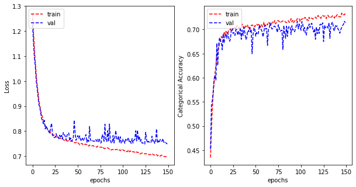

```python
# compile model
base_model.compile(optimizer='SGD',
              loss=tf.keras.losses.CategoricalCrossentropy(from_logits=True),
              metrics=['categorical_accuracy'])

# fit model
history_base_model = base_model.fit_generator(train_generator, validation_data = validation_generator, epochs=150, verbose=0)

# # plot model performance
plot_learning_curve(history_base_model.history['loss'], history_base_model.history['val_loss'],
                    history_base_model.history['categorical_accuracy'], history_base_model.history['val_categorical_accuracy'],
                    metric_name='Categorical Accuracy')
```

### Hyperparameters tuning for base model using Keras Tuner

We will be adding l2 regularization in this tuning as well as a dropout layer We will be using keras tuner to tune the following hyperparameters:

```python
import kerastuner as kt
from tensorflow import keras
from tensorflow.keras import layers

def model_builder(hp):
    # Dense layer unit value
    hp_units = hp.Int('units', min_value=32, max_value=256, step=32)
    # Regularization lambda value
    hp_reg_lambdas = hp.Choice('reg_lambda', values=[0.001, 0.005, 0.01])
    # dropout value
    hp_dropouts = hp.Float('dropout', min_value=0, max_value=0.3, step=0.1)

    # initialize layers
    model = tf.keras.Sequential([
        tf.keras.layers.Flatten(input_shape=INPUT_DIM),
        tf.keras.layers.Dense(units=hp_units, activation='sigmoid', kernel_regularizer=tf.keras.regularizers.l2(hp_reg_lambdas)),
        tf.keras.layers.Dropout(hp_dropouts),
        tf.keras.layers.Dense(OUTPUT_CLASSES, kernel_regularizer=tf.keras.regularizers.l2(hp_reg_lambdas))
    ])

    # compile model
    model.compile(optimizer='SGD',
              loss=tf.keras.losses.CategoricalCrossentropy(from_logits=True),
              metrics=['categorical_accuracy'])

    return model

# Instantiate the tuner and perform hypertuning
tuner_base_model = kt.Hyperband(model_builder,
                     objective='val_categorical_accuracy',
                     max_epochs=75,
                     factor=3,
                     directory='keras',
                     project_name='v1')

# Early stopping callback
stop_early = tf.keras.callbacks.EarlyStopping(monitor='val_loss', patience=5)

# extracting the image and labels from the generators as search function does not support generators directly
train_img,train_lables = train_generator.next()
val_img,val_lables = validation_generator.next()
```

```python
# Execute search
tuner_base_model.search(train_img,train_lables,
             validation_data=(val_img,val_lables),batch_size = 32, callbacks=[stop_early])

# Print optimal hyperparameters
best_hps_base_model=tuner_base_model.get_best_hyperparameters(num_trials=1)[0]

print(f"""
 units: {best_hps_base_model.get('units')}
 lamda: {best_hps_base_model.get('reg_lambda')}
 dropout: {best_hps_base_model.get('dropout')}
""")
```

```
Trial 90 Complete [00h 00m 03s]
val_categorical_accuracy: 0.4375

Best val_categorical_accuracy So Far: 0.5
Total elapsed time: 00h 02m 54s
INFO:tensorflow:Oracle triggered exit

 units: 160
 lamda: 0.001
 dropout: 0.2
```

Next we will build a model using the hyperparameters we got from keras tuner

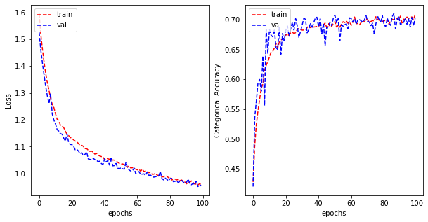

```python
# base_model_tuned
units = 160
reg_lambda = 0.001
dropout = 0.2
# initialize layers
base_model_tuned = tf.keras.Sequential([
        tf.keras.layers.Flatten(input_shape=INPUT_DIM),
        tf.keras.layers.Dense(units=units, activation="sigmoid", kernel_regularizer=tf.keras.regularizers.l2(reg_lambda)),
        tf.keras.layers.Dropout(dropout),
        tf.keras.layers.Dense(OUTPUT_CLASSES, kernel_regularizer=tf.keras.regularizers.l2(reg_lambda))
    ])

# compile model
base_model_tuned.compile(optimizer='SGD',
              loss=tf.keras.losses.CategoricalCrossentropy(from_logits=True),
              metrics=['categorical_accuracy'])

# fit model
history_base_model_tuned = base_model_tuned.fit_generator(train_generator, validation_data = validation_generator, epochs=100, verbose=0)

# plot model performance
plot_learning_curve(history_base_model_tuned.history['loss'], history_base_model_tuned.history['val_loss'],
                    history_base_model_tuned.history['categorical_accuracy'], history_base_model_tuned.history['val_categorical_accuracy'],
                    metric_name='Categorical Accuracy')
```

## Testing the base models

Testing the base models with our test set

```python
# Initialize test generator
test_data['cellType'] = test_data['cellType'].astype('str')
test_datagen = ImageDataGenerator(rescale=1./255, data_format='channels_last')
batch_size = 1
test_generator = test_datagen.flow_from_dataframe(
        dataframe=test_data,
        directory='./patch_images/',
        x_col="ImageName",
        y_col="cellType",
        target_size=(27, 27),
        batch_size=batch_size,
        class_mode='categorical')

test_img,test_labels = test_generator.next()
```

```
Found 1980 validated image filenames belonging to 4 classes.
```

```python
# Base model
base_model.evaluate(test_generator)
```

```
[0.7926315069198608, 0.7065656781196594]
```

```python
# Base model tuned
base_model_tuned.evaluate(test_generator)
```

```
[0.9867845177650452, 0.6984848380088806]
```

```python
# setup data some placeholders
y_hat_all = list()
y_all = list()
filenames = test_generator.filenames
N_images = len(filenames)
batches = 0

# iterate through the data generator and predict for each batch
# hold the predictions and labels
for x,y in test_generator:
        y_hat = base_model.predict(x, verbose=0)
        y_hat = np.argmax(y_hat, axis = 1)
        y = np.argmax(y, axis = 1)
        y_hat_all = y_hat_all + y_hat.tolist()
        y_all = y_all + y.tolist()

        batches += 1
        if batches >= N_images / batch_size:
            # we need to break the loop by hand because
            # the generator loops indefinitely
            break
```

```python
from sklearn.metrics import classification_report

print(classification_report(y_all, y_hat_all,))
```

```
              precision    recall  f1-score   support

           0       0.66      0.62      0.64       391
           1       0.65      0.76      0.70       497
           2       0.82      0.90      0.86       790
           3       0.41      0.23      0.29       302

    accuracy                           0.71      1980
   macro avg       0.64      0.63      0.62      1980
weighted avg       0.68      0.71      0.69      1980
```

```python
# setup data some placeholders
y_hat_all = list()
y_all = list()
filenames = test_generator.filenames
N_images = len(filenames)
batches = 0

# iterate through the data generator and predict for each batch
# hold the predictions and labels
for x,y in test_generator:
        y_hat = base_model_tuned.predict(x, verbose=0)
        y_hat = np.argmax(y_hat, axis = 1)
        y = np.argmax(y, axis = 1)
        y_hat_all = y_hat_all + y_hat.tolist()
        y_all = y_all + y.tolist()

        batches += 1
        if batches >= N_images / batch_size:
            # we need to break the loop by hand because
            # the generator loops indefinitely
            break
```

```python
from sklearn.metrics import classification_report

print(classification_report(y_all, y_hat_all,))
```

```
              precision    recall  f1-score   support

           0       0.63      0.64      0.63       391
           1       0.62      0.81      0.70       495
           2       0.83      0.88      0.85       792
           3       0.39      0.13      0.19       302

    accuracy                           0.70      1980
   macro avg       0.62      0.61      0.59      1980
weighted avg       0.67      0.70      0.67      1980
```

Obervation: We observe that the initial model without tuning has sligthly better performance overall considering metrics such as f1-score and categorical accuracy when tested on the test set. But the initial model has a little over-fitting and the tuned model was better regularized based on the learning curve graphs. Thus, we can say that it was just a small coincidence that the initial model had performed better on the test set, and that the tuned model would be the preferred pick to predict future unseen variables.

# 2) CNN model (using leNet)

Next we will experiment using CNN models, in this section we will attempt to create a CNN model using leNet. For this model we will also reduce the size of the dataset due to processing speed limitations, but we will make sure that the smaller data set is also a good representation of the entire set.

```python
# making data set smaller for faster compile

_, train_data_small = train_test_split(train_data, test_size=0.7, random_state=42)
_, test_data_small = train_test_split(test_data, test_size=0.7, random_state=42)
_, val_data_small = train_test_split(val_data, test_size=0.7, random_state=42)

print("Train data : {}, Val Data: {}, Test Data: {}".format(train_data_small.shape[0], test_data_small.shape[0], val_data_small.shape[0]))
```

```
Train data : 4156, Val Data: 1386, Test Data: 1386
```

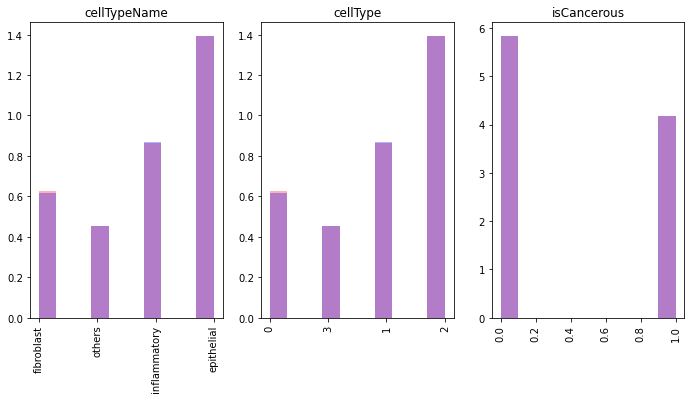

```python
# train set
plt.figure(figsize=(20,25))
for i, col in enumerate(['cellTypeName','cellType', 'isCancerous']):
    plt.subplot(4,5,i+1)
    _, bins, _ = plt.hist(train_data[col], alpha=0.3, color='r', density=True)
    plt.hist(train_data_small[col], bins=bins, alpha=0.3, color='b', density=True)
    plt.title(col)
    plt.xticks(rotation='vertical')
```

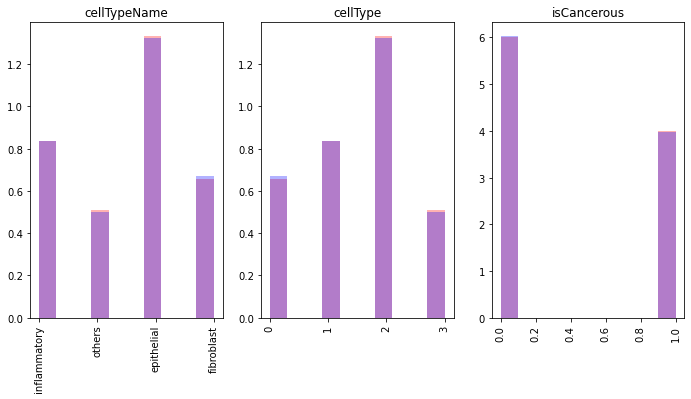

```python
# test set
plt.figure(figsize=(20,25))
for i, col in enumerate(['cellTypeName','cellType', 'isCancerous']):
    plt.subplot(4,5,i+1)
    _, bins, _ = plt.hist(test_data[col], alpha=0.3, color='r', density=True)
    plt.hist(test_data_small[col], bins=bins, alpha=0.3, color='b', density=True)
    plt.title(col)
    plt.xticks(rotation='vertical')
```

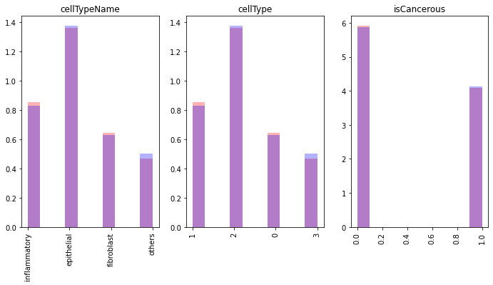

```python
# validation set
plt.figure(figsize=(20,25))
for i, col in enumerate(['cellTypeName','cellType', 'isCancerous']):
    plt.subplot(4,5,i+1)
    _, bins, _ = plt.hist(val_data[col], alpha=0.3, color='r', density=True)
    plt.hist(val_data_small[col], bins=bins, alpha=0.3, color='b', density=True)
    plt.title(col)
    plt.xticks(rotation='vertical')
```

We can observe that the varience in data distribution of the original set and the shrunk set is small, thus making them a good representation of their original sets.

```python
import tensorflow as tf
INPUT_DIM = (27,27,3)
OUTPUT_CLASSES = 4

from tensorflow.keras.preprocessing.image import ImageDataGenerator
train_datagen_small = ImageDataGenerator(rescale=1./255, data_format='channels_last')
val_datagen_small = ImageDataGenerator(rescale=1./255, data_format='channels_last')

batch_size = 32

train_generator_small = train_datagen_small.flow_from_dataframe(
        dataframe=train_data_small,
        directory='./patch_images/',
        x_col="ImageName",
        y_col="cellType",
        target_size=(27, 27),
        batch_size=batch_size,
        class_mode='categorical')

validation_generator_small = val_datagen_small.flow_from_dataframe(
        dataframe=val_data_small,
        directory='./patch_images/',
        x_col="ImageName",
        y_col="cellType",
        target_size=(27, 27),
        batch_size=batch_size,
        class_mode='categorical')
```

```
Found 4156 validated image filenames belonging to 4 classes.
Found 1386 validated image filenames belonging to 4 classes.
```

```
Model: "sequential"
_________________________________________________________________
Layer (type)                 Output Shape              Param #
=================================================================
lambda (Lambda)              (None, 27, 27, 1)         0
_________________________________________________________________
conv2d (Conv2D)              (None, 25, 25, 32)        320
_________________________________________________________________
activation (Activation)      (None, 25, 25, 32)        0
_________________________________________________________________
max_pooling2d (MaxPooling2D) (None, 12, 12, 32)        0
_________________________________________________________________
conv2d_1 (Conv2D)            (None, 10, 10, 32)        9248
_________________________________________________________________
activation_1 (Activation)    (None, 10, 10, 32)        0
_________________________________________________________________
conv2d_2 (Conv2D)            (None, 8, 8, 64)          18496
_________________________________________________________________
activation_2 (Activation)    (None, 8, 8, 64)          0
_________________________________________________________________
max_pooling2d_1 (MaxPooling2 (None, 4, 4, 64)          0
_________________________________________________________________
flatten (Flatten)            (None, 1024)              0
_________________________________________________________________
dense (Dense)                (None, 64)                65600
_________________________________________________________________
activation_3 (Activation)    (None, 64)                0
_________________________________________________________________
dropout (Dropout)            (None, 64)                0
_________________________________________________________________
dense_1 (Dense)              (None, 4)                 260
=================================================================
Total params: 93,924
Trainable params: 93,924
Non-trainable params: 0
_________________________________________________________________
```

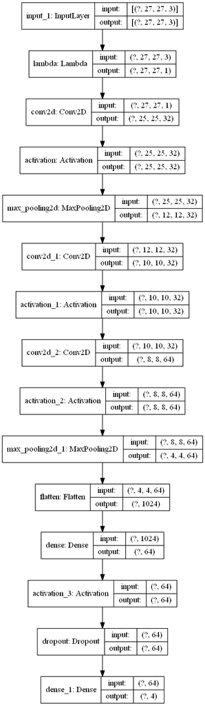

```python
reg_lambda = 0.001

model_leNet1 = tf.keras.Sequential([
    tf.keras.layers.Input(INPUT_DIM),
    tf.keras.layers.Lambda(lambda x: tf.expand_dims(x[:,:,:,0], -1, name=None)),


    tf.keras.layers.Conv2D(32, (3, 3), kernel_regularizer=tf.keras.regularizers.l2(reg_lambda)),
    tf.keras.layers.Activation('relu'),
    tf.keras.layers.MaxPool2D(pool_size=(2,2)),

    tf.keras.layers.Conv2D(32, (3, 3), kernel_regularizer=tf.keras.regularizers.l2(reg_lambda)),
    tf.keras.layers.Activation('relu'),

    tf.keras.layers.Conv2D(64, (3, 3)),
    tf.keras.layers.Activation('relu'),
    tf.keras.layers.MaxPool2D(pool_size=(2,2)),

    tf.keras.layers.Flatten(),

    tf.keras.layers.Dense(64),
    tf.keras.layers.Activation('relu'),
    tf.keras.layers.Dropout(0.5),
    tf.keras.layers.Dense(OUTPUT_CLASSES, activation='softmax', kernel_regularizer=tf.keras.regularizers.l2(reg_lambda))
])
model_leNet1.summary()
tf.keras.utils.plot_model(model_leNet1, show_shapes=True)
```

```
WARNING:tensorflow:From <ipython-input-64-72917af8395d>:6: Model.fit_generator (from tensorflow.python.keras.engine.training) is deprecated and will be removed in a future version.
Instructions for updating:
Please use Model.fit, which supports generators.
```

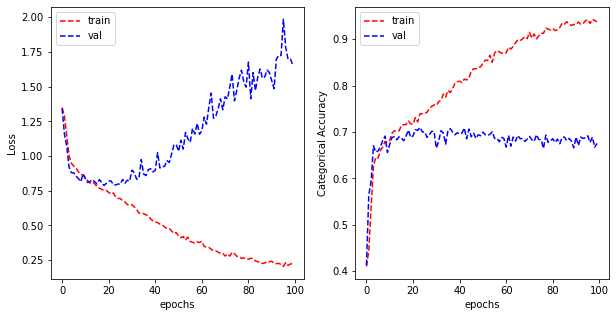

```python
sgd = tf.keras.optimizers.SGD(lr=0.01, decay=1e-6, momentum=0.9, nesterov=True)
model_leNet1.compile(optimizer=sgd,
              loss=tf.keras.losses.CategoricalCrossentropy(from_logits=False),
              metrics=['categorical_accuracy'])

history_leNet1 = model_leNet1.fit_generator(train_generator_small,
                                    validation_data = validation_generator_small,
                                    epochs=100, verbose=0)

plot_learning_curve(history_leNet1.history['loss'], history_leNet1.history['val_loss'],
                    history_leNet1.history['categorical_accuracy'], history_leNet1.history['val_categorical_accuracy'],
                    metric_name='Categorical Accuracy')
```

Observation: The model is over-fitted to the train set, thus we need to do some regularization on the model.

# Regularization using data augmentation

We will prepare a few data generators with different parameters of data augmentation and test their performance on models

```python
train_datagen_data_aug1 = ImageDataGenerator(rescale=1./255, data_format='channels_last',
                                  rotation_range=15, width_shift_range=0.2,
                                   height_shift_range=0.2)


train_generator_data_aug1 = train_datagen_data_aug1.flow_from_dataframe(
        dataframe=train_data_small,
        directory='./patch_images/',
        x_col="ImageName",
        y_col="cellType",
        target_size=(27, 27),
        batch_size=batch_size,
        class_mode='categorical')

# initialize optimizer
sgd = tf.keras.optimizers.SGD(lr=0.01, decay=1e-6, momentum=0.9, nesterov=True)
```

```
Found 4156 validated image filenames belonging to 4 classes.
```

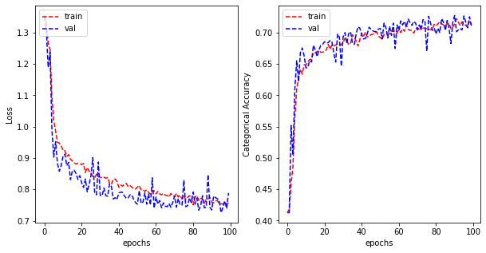

```python
model_leNet2 = tf.keras.Sequential([
    tf.keras.layers.Input(shape=(27, 27, 3)),
    tf.keras.layers.Lambda(lambda x: tf.expand_dims(x[:,:,:,0], -1, name=None)),


    tf.keras.layers.Conv2D(32, (3, 3), kernel_regularizer=tf.keras.regularizers.l2(reg_lambda)),
    tf.keras.layers.Activation('relu'),
    tf.keras.layers.MaxPool2D(pool_size=(2,2)),

    tf.keras.layers.Conv2D(32, (3, 3), kernel_regularizer=tf.keras.regularizers.l2(reg_lambda)),
    tf.keras.layers.Activation('relu'),

    tf.keras.layers.Conv2D(64, (3, 3)),
    tf.keras.layers.Activation('relu'),
    tf.keras.layers.MaxPool2D(pool_size=(2,2)),

    tf.keras.layers.Flatten(),

    tf.keras.layers.Dense(64),
    tf.keras.layers.Activation('relu'),
    tf.keras.layers.Dropout(0.5),
    tf.keras.layers.Dense(OUTPUT_CLASSES, activation='softmax', kernel_regularizer=tf.keras.regularizers.l2(reg_lambda))
])


model_leNet2.compile(optimizer=sgd,
              loss=tf.keras.losses.CategoricalCrossentropy(from_logits=False),
              metrics=['categorical_accuracy'])

history_leNet2 = model_leNet2.fit_generator(train_generator_data_aug1,
                                    validation_data = validation_generator_small,
                                    epochs=100, verbose=0)

plot_learning_curve(history_leNet2.history['loss'], history_leNet2.history['val_loss'],
                    history_leNet2.history['categorical_accuracy'], history_leNet2.history['val_categorical_accuracy'],
                    metric_name='Categorical Accuracy')
```